# Forecasting Hourly Energy Demand in Luzon

*Analysis and notebook prepared by:*  
**Matthew C. Romero**  
Master of Science in Data Science 2021  
Asian Institute of Management

For more information, email: **MatthewRomero.MSDS2021@aim.edu**  
*Ad Majorem dei Gloriam*

INTRODUCTION

The energy demand in Luzon keeps on growing each year. Many societal factors play a part in the energy generation and consumption of people in the largest island in the country and as such, experts as forecasting huge megawatt peaks in the year 2020. NGCP (National Grid Corporation) themselves said that Luzon will peak at around 12,286 megawatts during the dry season of the year. This growth though is still in line with the performance seen in the past months. Thus, forecasting the accurate demand per day is imperative, especially now that the country is slowly being overrun by the pandemic. More and more people have been staying inside their homes, in turn increasing each household's energy consumption in Luzon.

As mentioned earlier, accuracy in energy demand forecasting must be done with utmost importance and care. Allocating too much energy demand for a given time will result in energy wastage and more pollution. On the other hand, allocating little demand will result in more blackouts within the island. Such results are unfavorable at best. Thus, there is a need to have a method or procedure in which forecasting energy demand over the next hour will be as close to the real generated energy demand as possible.

PROBLEM STATEMENT

In dealing with forecasting energy, accuracy should be of high regard. As per the source of this data, a plus-minus of 3% is the industry standard for forecasts. The problem however is that there is no way to accurately predict what the energy demand will be. Even if seasonality and past trends were used in computations, it's always a gamble to say that this certain figure will be the exact demand. An incorrect prediction, no matter how small, is costly but that's the price one has to pay.

The aim of this analysis, however, is to not submit to those thresholds, but rather to make an accurate forecast as close to the real value as possible. Thus, in this analysis, I sought to answer the following question: **How can we create an almost-accurate energy demand forecasting model for Luzon?**

The answer may lie in the use of **Machine Learning.**

EXPERIMENTS

### *Data*

The data was given to me by an employee of a private energy trading agency. It has around 1 year worth energy demand listed at hourly intervals. For this analysis however, data from May to July was used. I assumed that using three months of hourly data is enough to capture a trend on energy demand.

### *Terminologies*

Some of the following terms will be seen in the dataset and for clarity, these are defined here:

- **DAP:** Day Ahead Prediction. Initial predictions done by the company.
- **RTX:** Real Time Ex-post. Real time demand recorded.
- **RTD:** Real Time Dispatch. Initial demand recorded within the first few minutes of the hour
- **Features/Columns:** Variables that are essential for determining the outcome of the machine learning model.
- **Classification/Regression:** Types of the machine learning model. Classification models have an outcome of categorical data and regression models have an outcome of continuous, often numerical variables.

### *Methodology*

The following was the pipeline followed regarding this analysis:

1. Data Wrangling of available data
2. Exploratory Data Analysis
3. Establishing a baseline
4. Creation of the machine learning model
5. Analysis and discussion of the results
6. Discussion of Highlights
7. Conclusion and Learnings

The rest of the process and codes are displayed below.

```python
import numpy as np
import pandas as pd
import matplotlib.pyplot as plt
import seaborn as sns

from sklearn.model_selection import train_test_split

from sklearn.ensemble import AdaBoostRegressor
from sklearn.tree import DecisionTreeRegressor
from sklearn.ensemble import RandomForestRegressor
from sklearn.ensemble import GradientBoostingRegressor
from sklearn.linear_model import LinearRegression
from sklearn.neighbors import KNeighborsRegressor
from sklearn.svm import SVR

from sklearn.metrics import mean_absolute_error
from sklearn.metrics import mean_squared_error
from math import sqrt

from numpy import mean
from numpy import std
from sklearn.datasets import make_classification
from sklearn.model_selection import KFold
from sklearn.model_selection import cross_val_score
from sklearn.linear_model import LogisticRegression
from sklearn.metrics import r2_score
```

THE DATASET

This data was provided by a friend who works in a private energy trading company that allocates non-renewable and renewable energy for the whole island of Luzon and he provided me with 3 months worth of hourly data. Their current problem was that they wanted to find out if one can predict hourly energy demand based on expected temperature and weather data. The data had these features:

| feature | meaning | data type |
| --- | --- | --- |
| **Date** | recorded date of demand | datetime |
| **Month** | month derived from date | str |
| **Day** | day of the week | str |
| **Interval** | refers to the hours within the day | float |
| **DAP DEMAND** | day-ahead prediction. the initial day ahead forecasts of the company | float |
| **RTD DEMAND** | real time demand. initial deman recorded at the start of interval | float |
| **RTX DEMAND** | real-time expost. total demand recorded for an interval | float |
| **Temp** | day temperature | int |
| **Weather** | forecasted weather condition | str |
| **Wind** | forecasted wind conditions | int |
| **Humidity** | forecasted humidity measure | int |

**Figure 1:** Initial Dataset

```python
df = pd.read_csv('forecast_2020_v2.csv')
df = df.drop('Unnamed: 0', axis=1)
df.drop(df.index[1920:], inplace=True)
df_copy = df.copy()
df_copy.head()
```

|  | Date | Month | Day | Interval | DAP DEMAND | RTD DEMAND | RTX DEMAND | Temp | Weather | Wind | Humidity |
| --- | --- | --- | --- | --- | --- | --- | --- | --- | --- | --- | --- |
| 0 | 01/05/2020 | May | Fri | 1 | 7481.1 | 7524.1 | 7446.7 | 26 | Passing clouds | 0 | 73 |
| 1 | 01/05/2020 | May | Fri | 2 | 7244.2 | 7215.0 | 7170.4 | 26 | Passing clouds | 0 | 73 |
| 2 | 01/05/2020 | May | Fri | 3 | 6976.1 | 6924.8 | 6881.8 | 26 | Passing clouds | 0 | 73 |
| 3 | 01/05/2020 | May | Fri | 4 | 6718.5 | 6698.1 | 6623.2 | 26 | Passing clouds | 0 | 73 |
| 4 | 01/05/2020 | May | Fri | 5 | 6457.6 | 6460.0 | 6429.6 | 24 | Passing clouds | 2 | 83 |

**Figure 2:** Initial Dataset

DATA WRANGLING

To make the data easier to analyze, some features were derived to better understand how the data would look like. The intervals were labeled based on what time of the day it was and the `Day` was labeled *weekend* or *weekday*. Some columns were renamed as well for easier coding.

```python
def interval_label(row):
    if row['Interval'] >= 1 and row['Interval'] < 6 or row['Interval'] == 24:
        return 'Dawn'
    elif row['Interval'] >= 6 and row['Interval'] < 12:
        return 'Morning'
    elif row['Interval'] >= 12 and row['Interval'] <= 17:
        return 'Afternoon'
    else:
        return 'Evening'

def label_day(row):
    if row['Day'] == 'Sat':
        return 'Weekend'
    elif row['Day'] == 'Sun':
        return 'Weekend'
    else:
        return 'Weekday'

df_copy['Date'] = df_copy['Date'].str.split('/', expand=True).drop([0, 2], axis=1)
df_copy['day_category'] = df_copy.apply(lambda row: label_day(row), axis=1 )
df_copy['interval_label'] = df_copy.apply(lambda row: interval_label(row), axis=1)
df_copy = df_copy.rename(columns={'DAP DEMAND':'DAP', 'RTD DEMAND':'RTD',
                                  'RTX DEMAND': 'RTX'})
df_copy = df_copy.dropna()
```

Prior to proceeding with the analysis, some features will be *one hot encoded*. Since these are categorical labels, one-hot encoding them will make it easier for the model to analyze them.

```python
df_copy = df_copy.drop(['Date', 'Wind'], axis=1)
df_copy = pd.get_dummies(df_copy, columns=['Month', 'Day', 'Weather',
                                           'Interval', 'day_category',
                                          'interval_label'])

df_copy = df_copy.drop('Weather_0', axis=1)
```

EXPLORATORY DATA ANALYSIS

Let's now try to investigate and see what we can gather from the data through exploratory data analysis.

### What's Luzon's energy hourly energy consumption for the past three months?

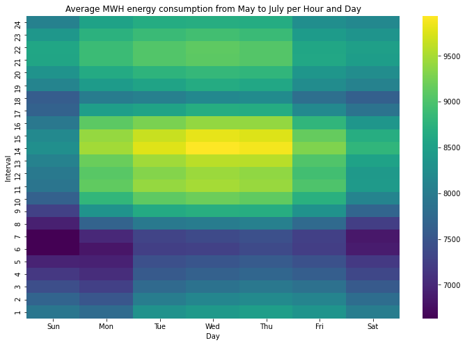

```python
df_eda = df
df_eda = df_eda.pivot_table(values='RTX DEMAND', index='Interval', columns = 'Day', aggfunc = 'mean')
df_eda = df_eda[['Sun', 'Mon', 'Tue', 'Wed', 'Thu', 'Fri', 'Sat']]

plt.figure(figsize=(12, 8))
ax = sns.heatmap(df_eda.sort_index(ascending = False), cmap='viridis')
plt.title('Average MWH energy consumption from May to July per Hour and Day')
plt.show()
```

**Figure 3:** Average hourly RTX Demands for the past 3 months.

Here are some insights we could come up with:

### How much energy are we consuming?

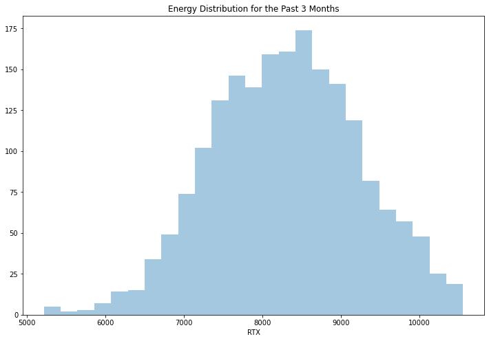

```python
plt.figure(figsize=(12, 8))
sns.distplot(df_copy['RTX'], kde=False)
plt.title('Energy Distribution for the Past 3 Months')
plt.show()
```

**Figure 4:** Distribution plot of RTX demands for the past 3 months.

### How accurate is the DAP demand forecasting model of the company?

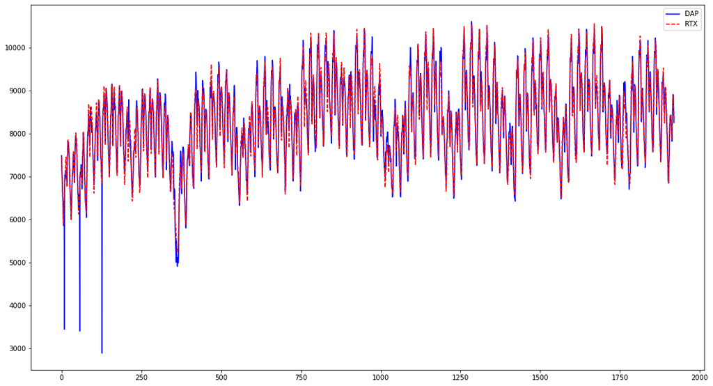

```python
# DAP- Day Ahead Projection
# RTX- Real Time Expost
# RTD- Real Time Dispatch
fig, ax = plt.subplots(figsize=(18, 10))
ax.plot(df_copy['DAP'], 'b', label = 'DAP')
ax.plot(df_copy['RTX'], 'r--', label = 'RTX')
ax.legend()
plt.show()
```

**Figure 5:** Comparison between `DAP` and `RTX`

ESTABLISHING A BASELINE

Prior to creating a model, error statistics for the the initial DAP Demand was calculated.

```python
#Calculating MAE, MSE and MAPE
def mean_absolute_percentage_error(y_true, y_pred):
    y_true, y_pred = np.array(y_true), np.array(y_pred)
    return np.mean(np.abs((y_true - y_pred) / y_true)) * 100

MAPE = mean_absolute_percentage_error(df_copy.RTX, df_copy.DAP)
MAE = mean_absolute_error(df_copy.RTX, df_copy.DAP)
RMSE = sqrt(mean_squared_error(df_copy.RTX, df_copy.DAP))
R2 = r2_score(df_copy.RTX, df_copy.DAP)

columns = ['model', 'MAE', 'RMSE', 'MAPE', 'R2']
errors = pd.DataFrame(columns=columns)
errors.loc[0] = ['initial', MAE, RMSE, MAPE, R2]
errors
```

|  | model | MAE | RMSE | MAPE | R2 |
| --- | --- | --- | --- | --- | --- |
| 0 | initial | 121.98 | 222.310206 | 1.504126 | 0.943811 |

**Figure 6:** Baseline Error-Calculations for the Current `DAP` Forecasts

MODEL CREATION

```python
y = df_copy['RTX']
X = df_copy.drop(['RTX'], axis=1)

X1 = X.copy()
X1 = X1.drop(['DAP', 'RTD'], axis=1)
```

```python
X_train, X_test, y_train, y_test = train_test_split(X1, y, test_size=0.25, random_state=1)

#Date
# X_train, X_val, y_train, y_val = train_test_split(X_train, y_train, test_size=0.25, random_state=1) # 0.25 x 0.8 = 0.2
```

```python
LR = LinearRegression()
LR.fit(X_train, y_train)
AD = AdaBoostRegressor(random_state=1)
AD.fit(X_train, y_train)
DT = DecisionTreeRegressor(random_state=1)
DT.fit(X_train,y_train)
RF = RandomForestRegressor(random_state=1, n_estimators=1000,
                           min_samples_split=2, max_features=15, bootstrap = False )
RF.fit(X_train,y_train)
GB = GradientBoostingRegressor(random_state=1, learning_rate=0.3,
                               n_estimators=1000, max_features=7)
GB.fit(X_train,y_train)
SV = SVR()
SV.fit(X_train, y_train)
KNN = KNeighborsRegressor(n_neighbors = 4)
KNN.fit(X_train, y_train)

cols = ['Machine Learning Regression Method','Train Accuracy', 'Test Accuracy']
df2 = pd.DataFrame(columns=cols)
df2.loc[0] = ['Decision Tree',DT.score(X_train, y_train), DT.score(X_test, y_test)]
df2.loc[1] = ['Random Forest',RF.score(X_train, y_train), RF.score(X_test, y_test)]
df2.loc[2] = ['Gradient Boosting', GB.score(X_train, y_train), GB.score(X_test, y_test)]
df2.loc[3] = ['Ada Boost',AD.score(X_train, y_train), AD.score(X_test, y_test)]
df2.loc[4] = ['Linear Regression',LR.score(X_train, y_train), LR.score(X_test, y_test)]
df2.loc[5] = ['SVR',SV.score(X_train, y_train), SV.score(X_test, y_test)]
df2.loc[6] = ['KNN',KNN.score(X_train, y_train), KNN.score(X_test, y_test)]
pass
df2
```

|  | Machine Learning Regression Method | Train Accuracy | Test Accuracy |
| --- | --- | --- | --- |
| 0 | Decision Tree | 0.998673 | 0.786566 |
| 1 | Random Forest | 0.998673 | 0.899319 |
| 2 | Gradient Boosting | 0.975089 | 0.890778 |
| 3 | Ada Boost | 0.659428 | 0.675215 |
| 4 | Linear Regression | 0.798363 | 0.744686 |
| 5 | SVR | 0.026950 | 0.017243 |
| 6 | KNN | 0.874216 | 0.784805 |

**Figure 7:** Result of all regression models.

DISCUSSION OF RESULTS

To check the robustness of the model, I tried to re-predict the RTX demands of the data available using the RF model. And comparing it with the DAP, it surely had a better accuracy and lower error scores.

```python
X['RF'] = RF.predict(X1)
X['GB'] = GB.predict(X1)
y_hat = RF.predict(X1)
X['RTX'] = df_copy['RTX']
X['DAP'] = df_copy['DAP']
```

The model was able to predict the RTX models as accurate and as close as possible. There are no huge dips in the predictions, suggesting that indeed it could be used to predict unknown data.

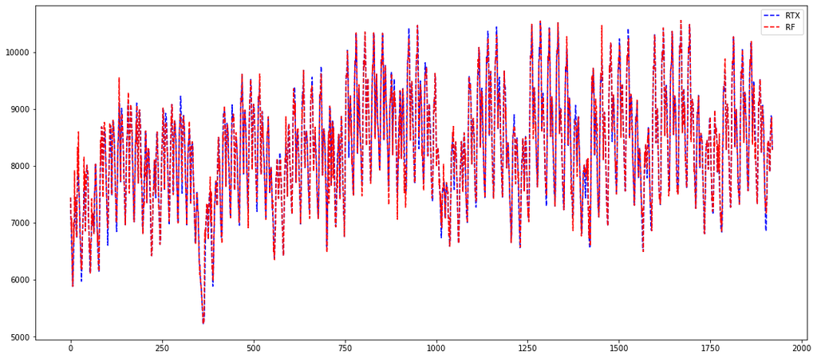

```python
plt.figure(figsize=(18,8))
plt.plot(X['RTX'], 'b--', label = 'RTX')
plt.plot(X['RF'], 'r--', label = 'RF')
# plt.plot(X['GB'], 'g--', label = 'GB')
plt.legend()
plt.show()
```

**Figure 8:** Comparison between `RF MODEL` and `RTX`

```python
MAPE1 = mean_absolute_percentage_error(X.RTX, X.RF)
MAE1 = mean_absolute_error(X.RTX, X.RF)
RMSE1 = sqrt(mean_squared_error(X.RTX, X.RF))
R21 = r2_score(X.RTX, X.RF)

MAPE2 = mean_absolute_percentage_error(X.RTX, X.GB)
MAE2 = mean_absolute_error(X.RTX, X.GB)
RMSE2 = sqrt(mean_squared_error(X.RTX, X.GB))
R22 = r2_score(X.RTX, X.GB)
```

```python
errors.loc[1] = ['Random Forest Model', MAE1, RMSE1, MAPE1, R21]
errors.loc[2] = ['Gradient Boosting', MAE2, RMSE2, MAPE2, R22]
errors
```

|  | model | MAE | RMSE | MAPE | R2 |
| --- | --- | --- | --- | --- | --- |
| 0 | initial | 121.980000 | 222.310206 | 1.504126 | 0.943811 |
| 1 | Random Forest Model | 60.274762 | 152.087093 | 0.753686 | 0.973702 |
| 2 | Gradient Boosting | 138.505071 | 201.289096 | 1.708174 | 0.953935 |

**Figure 9:** Error statistics for the top 2 best ML Models.

Shown here below are the feature importances identified in the data set.

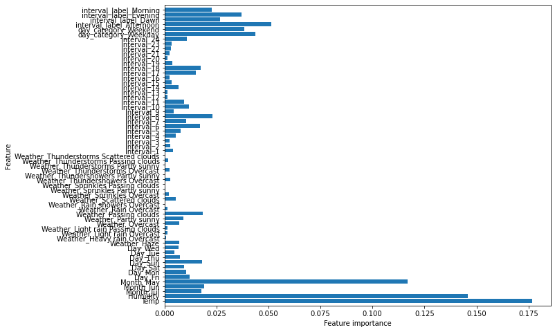

```python
def plot_feature_importances_energy(model):
    n_features=X1.shape[1]
    plt.barh(range(n_features), model.feature_importances_, align='center')
    plt.yticks(np.arange(n_features), X1.columns)
    plt.xlabel("Feature importance")
    plt.ylabel("Feature")
    plt.ylim(-1,n_features)

plt.figure(figsize=(10,8))
plot_feature_importances_energy(RF)
```

**Figure 10:** Important Features.

We can see that temperature and other weather data were the top predictors. This proves to us that temperature and weather readings are very important to know how much energy will be allocated for the whole island. If the hour is expected to be colder, of course lesser energy must be allocated, and the opposite is when the hour is expected to have peak high temperatures.

KEY LEARNINGS

REFERENCES

[1] Hyndman, Rob and George Athanasopoulos. **Forecasting: Principles and Practice** *Monash University, Australia* https://otexts.com/fpp2/

[2] Pawar, Prathamesh. **Predicting Hourly Energy consumption of San Diego — II** https://towardsdatascience.com/part-2-time-series-analysis-predicting-hourly-energy-consumption-of-san-diego-ii-f09665796c9

[3] Son, Hyojoo and Changwan Kim. **A Deep Learning Approach to Forecasting Monthly Demand for Residential–Sector Electricity** *Sustainability 2020, 12, 3103*